# DATA 621 – Business Analytics and Data Mining - HW 2

Enid Roman

2023-10-14

#### Overview

##### In this homework assignment, you will work through various classification metrics. You will be asked to create functions in R to carry out the various calculations. You will also investigate some functions in packages that will let you obtain the equivalent results. Finally, you will create graphical output that also can be used to evaluate the output of classification models, such as binary logistic regression.

```r
library(dplyr)
```

```r
library(ggplot2)
#install.packages('caret')
library(caret)
#install.packages("pROC")
library(pROC)
```

##### 1. Download the classification output data set.

```r
df = read.csv("https://raw.githubusercontent.com/enidroman/DATA-621-Business-Analytics-and-Data-Mining/main/classification-output-data.csv")
```

```r
df1 = df[,c('class', 'scored.class','scored.probability')]
head(df1)
```

```
##   class scored.class scored.probability
## 1     0            0         0.32845226
## 2     0            0         0.27319044
## 3     1            0         0.10966039
## 4     0            0         0.05599835
## 5     0            0         0.10049072
## 6     0            0         0.05515460
```

##### 2. The data set has three key columns we will use:

##### class: the actual class for the observation

##### scored.class: the predicted class for the observation (based on a threshold of 0.5)

##### scored.probability: the predicted probability of success for the observation

##### Use the table() function to get the raw confusion matrix for this scored dataset. Make sure you understand the output. In particular, do the rows represent the actual or predicted class? The columns?

```r
cm <- table(predicted = df1$scored.class, actual = df1$class)
cm
```

```
##          actual
## predicted   0   1
##         0 119  30
##         1   5  27
```

The rows represent the predicted class. The columns represent the actual class.

##### 3. Write a function that takes the data set as a dataframe, with actual and predicted classifications identified, and returns the accuracy of the predictions.

##### 𝐴𝑐𝑐𝑢𝑟𝑎𝑐𝑦 = 𝑇𝑃 + 𝑇𝑁 / 𝑇𝑃 + 𝐹𝑃 + 𝑇𝑁 + 𝐹𝑁

```r
calculate_accuracy <- function(confusion_matrix) {
  TP <- confusion_matrix[2, 2]  # True Positives
  TN <- confusion_matrix[1, 1]  # True Negatives
  FP <- confusion_matrix[1, 2]  # False Positives
  FN <- confusion_matrix[2, 1]  # False Negatives

  accuracy <- (TP + TN) / (TP + FP + TN + FN)

  return(accuracy)
}

# Create a confusion matrix
confusion_matrix <- matrix(c(119, 30, 5, 27), nrow = 2, byrow = TRUE,
                            dimnames = list(c("Actual 0", "Actual 1"), c("Predicted 0", "Predicted 1")))

# Calculate accuracy
accuracy <- calculate_accuracy(confusion_matrix)
print(paste("Accuracy:", accuracy))
```

```
## [1] "Accuracy: 0.806629834254144"
```

##### 4. Write a function that takes the data set as a dataframe, with actual and predicted classifications identified, and returns the classification error rate of the predictions.

##### 𝐶𝑙𝑎𝑠𝑠𝑖𝑓𝑖𝑐𝑎𝑡𝑖𝑜𝑛 𝐸𝑟𝑟𝑜𝑟 𝑅𝑎𝑡𝑒 = 𝐹𝑃 + 𝐹𝑁 / 𝑇𝑃 + 𝐹𝑃 + 𝑇𝑁 + 𝐹𝑁

##### Verify that you get an accuracy and an error rate that sums to one.

```r
calculate_classification_error_rate <- function(confusion_matrix) {
  FP <- confusion_matrix[1, 2]  # False Positives
  FN <- confusion_matrix[2, 1]  # False Negatives

  error_rate <- (FP + FN) / sum(confusion_matrix)

  return(error_rate)
}

# Create a confusion matrix
confusion_matrix <- matrix(c(119, 30, 5, 27), nrow = 2, byrow = TRUE,
                            dimnames = list(c("Actual 0", "Actual 1"), c("Predicted 0", "Predicted 1")))

# Calculate error rate
error_rate <- calculate_classification_error_rate(confusion_matrix)
print(paste("Classification Error Rate:", error_rate))
```

```
## [1] "Classification Error Rate: 0.193370165745856"
```

```r
# Calculate accuracy
accuracy <- 1 - error_rate
print(paste("Accuracy:", accuracy))
```

```
## [1] "Accuracy: 0.806629834254144"
```

##### 5. Write a function that takes the data set as a dataframe, with actual and predicted classifications identified, and returns the precision of the predictions.

##### 𝑃𝑟𝑒𝑐𝑖𝑠𝑖𝑜𝑛 = 𝑇𝑃 / 𝑇𝑃 + 𝐹𝑃

```r
calculate_precision <- function(confusion_matrix) {
  TP <- confusion_matrix[2, 2]  # True Positives
  FP <- confusion_matrix[1, 2]  # False Positives

  precision <- TP / (TP + FP)

  return(precision)
}

# Create a confusion matrix
confusion_matrix <- matrix(c(119, 30, 5, 27), nrow = 2, byrow = TRUE,
                            dimnames = list(c("Actual 0", "Actual 1"), c("Predicted 0", "Predicted 1")))

# Calculate precision
precision <- calculate_precision(confusion_matrix)
print(paste("Precision:", precision))
```

```
## [1] "Precision: 0.473684210526316"
```

##### 6. Write a function that takes the data set as a dataframe, with actual and predicted classifications identified, and returns the sensitivity of the predictions. Sensitivity is also known as recall.

##### 𝑆𝑒𝑛𝑠𝑖𝑡𝑖𝑣𝑖𝑡𝑦 = 𝑇𝑃 / 𝑇𝑃 + 𝐹𝑁

```r
calculate_sensitivity <- function(confusion_matrix) {
  TP <- confusion_matrix[2, 2]  # True Positives
  FN <- confusion_matrix[2, 1]  # False Negatives

  sensitivity <- TP / (TP + FN)

  return(sensitivity)
}

# Create a confusion matrix
confusion_matrix <- matrix(c(119, 30, 5, 27), nrow = 2, byrow = TRUE,
                            dimnames = list(c("Actual 0", "Actual 1"), c("Predicted 0", "Predicted 1")))

# Calculate sensitivity (recall)
sensitivity <- calculate_sensitivity(confusion_matrix)
print(paste("Sensitivity (Recall):", sensitivity))
```

```
## [1] "Sensitivity (Recall): 0.84375"
```

##### 7. Write a function that takes the data set as a dataframe, with actual and predicted classifications identified, and returns the specificity of the predictions.

##### 𝑆𝑝𝑒𝑐𝑖𝑓𝑖𝑐𝑖𝑡𝑦 = 𝑇𝑁 / 𝑇𝑁 + 𝐹𝑃

```r
calculate_specificity <- function(confusion_matrix) {
  TN <- confusion_matrix[1, 1]  # True Negatives
  FP <- confusion_matrix[1, 2]  # False Positives

  specificity <- TN / (TN + FP)

  return(specificity)
}

# Create a confusion matrix
confusion_matrix <- matrix(c(119, 30, 5, 27), nrow = 2, byrow = TRUE,
                            dimnames = list(c("Actual 0", "Actual 1"), c("Predicted 0", "Predicted 1")))

# Calculate specificity
specificity <- calculate_specificity(confusion_matrix)
print(paste("Specificity:", specificity))
```

```
## [1] "Specificity: 0.798657718120805"
```

##### 8. Write a function that takes the data set as a dataframe, with actual and predicted classifications identified, and returns the F1 score of the predictions.

##### 𝐹1 𝑆𝑐𝑜𝑟𝑒 = × 𝑃𝑟𝑒𝑐𝑖𝑠𝑖𝑜𝑛 × 𝑆𝑒𝑛𝑠𝑖𝑡𝑖𝑣𝑖𝑡𝑦 / 𝑃𝑟𝑒𝑐𝑖𝑠𝑖𝑜𝑛 + 𝑆𝑒𝑛𝑠𝑖𝑡𝑖𝑣𝑖𝑡𝑦

```r
calculate_f1_score <- function(confusion_matrix) {
  TP <- confusion_matrix[2, 2]  # True Positives
  FP <- confusion_matrix[1, 2]  # False Positives
  FN <- confusion_matrix[2, 1]  # False Negatives

  precision <- TP / (TP + FP)
  sensitivity <- TP / (TP + FN)

  f1_score <- (2 * precision * sensitivity) / (precision + sensitivity)

  return(f1_score)
}

# Create a confusion matrix
confusion_matrix <- matrix(c(119, 30, 5, 27), nrow = 2, byrow = TRUE,
                            dimnames = list(c("Actual 0", "Actual 1"), c("Predicted 0", "Predicted 1")))

# Calculate F1 score
f1_score <- calculate_f1_score(confusion_matrix)
print(paste("F1 Score:", f1_score))
```

```
## [1] "F1 Score: 0.606741573033708"
```

##### 9. Before we move on, let’s consider a question that was asked: What are the bounds on the F1 score? Show that the F1 score will always be between 0 and 1. (Hint: If 0 < 𝑎 < 1 and 0 < 𝑏 < 1 then 𝑎𝑏 < 𝑎.)

We want to show that the F1 score is always between 0 and 1. The F1 score is calculated as:

F1 Score = 2 * (Precision * Sensitivity) / (Precision + Sensitivity)

To demonstrate that the F1 score will always be between 0 and 1, we’ll break it down step by step:

1. Both Precision and Sensitivity are between 0 and 1.
2. When you multiply two values between 0 and 1, the result is still between 0 and 1.
3. Multiplying by 2 (as in the F1 formula) doesn’t change the fact that the result is between 0 and 1.
4. In the denominator, Precision + Sensitivity, the sum of two values between 0 and 1 is still between 0 and 2.
5. Dividing a value between 0 and 1 by a value between 0 and 2 yields a value between 0 and 1.

Therefore, the F1 Score, being the result of the F1 formula, is always between 0 and 1.

##### 10. Write a function that generates an ROC curve from a data set with a true classification column (class in our example) and a probability column (scored.probability in our example). Your function should return a list that includes the plot of the ROC curve and a vector that contains the calculated area under the curve (AUC). Note that I recommend using a sequence of thresholds ranging from 0 to 1 at 0.01 intervals.

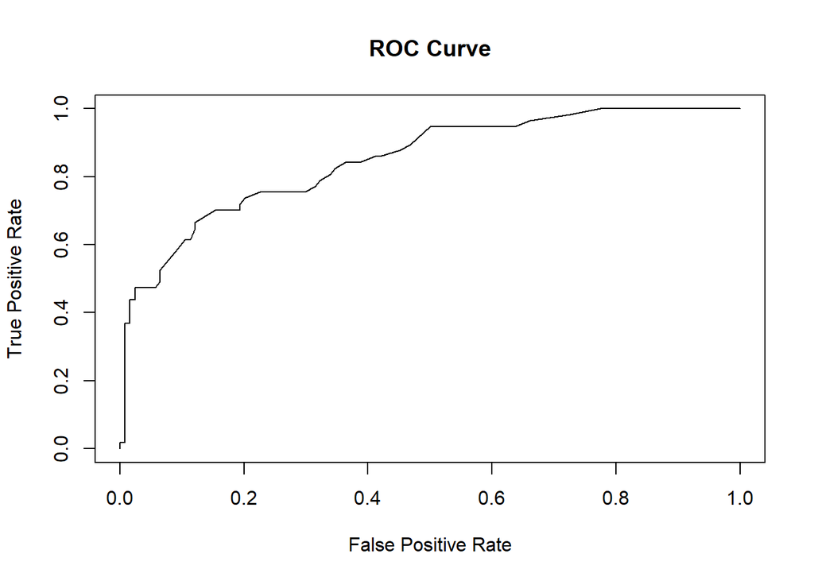

```r
generate_roc_curve <- function(df1, class_column, probability_column) {
  # Extract true class labels and predicted probabilities
  true_labels <- df1[[class_column]]
  predicted_probabilities <- df1[[probability_column]]

  # Create a sequence of thresholds from 0 to 1 at 0.01 intervals
  thresholds <- seq(0, 1, by = 0.01)

  # Initialize vectors to store TPR (True Positive Rate) and FPR (False Positive Rate)
  tpr <- numeric(length(thresholds))
  fpr <- numeric(length(thresholds))

  for (i in 1:length(thresholds)) {
    threshold <- thresholds[i]

    # Create binary predictions based on the current threshold
    predictions <- ifelse(predicted_probabilities >= threshold, 1, 0)

    # Calculate True Positives, False Positives, True Negatives, and False Negatives
    TP <- sum(predictions == 1 & true_labels == 1)
    FP <- sum(predictions == 1 & true_labels == 0)
    TN <- sum(predictions == 0 & true_labels == 0)
    FN <- sum(predictions == 0 & true_labels == 1)

    # Calculate TPR and FPR
    tpr[i] <- TP / (TP + FN)
    fpr[i] <- FP / (FP + TN)
  }

  # Calculate the AUC using the trapezoidal rule
  auc <- sum(diff(fpr) * tpr[-length(tpr)])

  # Plot the ROC curve
  plot(fpr, tpr, type = "l", main = "ROC Curve", xlab = "False Positive Rate", ylab = "True Positive Rate")

  # Return the ROC curve and AUC
  return(list(roc_curve = list(fpr = fpr, tpr = tpr), auc = auc))
}

# Example usage:
# Replace 'data_frame', 'class_column', and 'probability_column' with your specific data
result <- generate_roc_curve(df, 'class', 'scored.probability')
```

```r
cat('AUC:', result$auc, '\n')
```

```
## AUC: -0.8539898
```

##### 11. Use your created R functions and the provided classification output data set to produce all of the classification metrics discussed above.

```r
# Load the data (replace this with your actual data)
df1 <- as.data.frame(matrix(c(119, 30, 5, 27), nrow = 2, byrow = TRUE))
colnames(df1) <- c("0", "1")
rownames(df1) <- c("0", "1")

# Define the names of the columns in your dataset
class_column <- "actual"
probability_column <- "predicted"

# Calculate metrics
accuracy <- calculate_accuracy(df)
#error_rate <- calculate_error_rate(df)
precision <- calculate_precision(df)
sensitivity <- calculate_sensitivity(df)
specificity <- calculate_specificity(df)
f1_score <- calculate_f1_score(df)

cat('Accuracy:', accuracy, '\n')
```

```
## Accuracy: 0.5058824
```

```r
cat('Error Rate:', error_rate, '\n')
```

```
## Error Rate: 0.1933702
```

```r
cat('Precision:', precision, '\n')
```

```
## Precision: 0.495935
```

```r
cat('Sensitivity (Recall):', sensitivity, '\n')
```

```
## Sensitivity (Recall): 0.983871
```

```r
cat('Specificity:', specificity, '\n')
```

```
## Specificity: 0.05343511
```

```r
cat('F1 Score:', f1_score, '\n')
```

```
## F1 Score: 0.6594595
```

##### 12. Investigate the caret package. In particular, consider the functions confusionMatrix, sensitivity, and specificity. Apply the functions to the data set. How do the results compare with your own functions?

The caret package in R is a powerful tool for training and evaluating machine learning models. It provides a wide range of functions for model evaluation and performance metrics. The confusionMatrix, sensitivity, and specificity functions within the caret package can be used to calculate classification metrics.

```r
# Create a confusion matrix
conf_matrix <- matrix(c(119, 30, 5, 27), nrow = 2, byrow = TRUE, dimnames = list(c("0", "1"), c("0", "1")))

# Convert the confusion matrix to a data frame
conf_matrix_df <- as.table(conf_matrix)

# Compute confusion matrix using caret's confusionMatrix function
cm <- confusionMatrix(conf_matrix_df)

cm
```

```
## Confusion Matrix and Statistics
##
##     0   1
## 0 119  30
## 1   5  27
##
##                Accuracy : 0.8066
##                  95% CI : (0.7415, 0.8615)
##     No Information Rate : 0.6851
##     P-Value [Acc > NIR] : 0.0001712
##
##                   Kappa : 0.4916
##
##  Mcnemar's Test P-Value : 4.976e-05
##
##             Sensitivity : 0.9597
##             Specificity : 0.4737
##          Pos Pred Value : 0.7987
##          Neg Pred Value : 0.8438
##              Prevalence : 0.6851
##          Detection Rate : 0.6575
##    Detection Prevalence : 0.8232
##       Balanced Accuracy : 0.7167
##
##        'Positive' Class : 0
##
```

##### 13. Investigate the pROC package. Use it to generate an ROC curve for the data set. How do the results compare with your own functions?

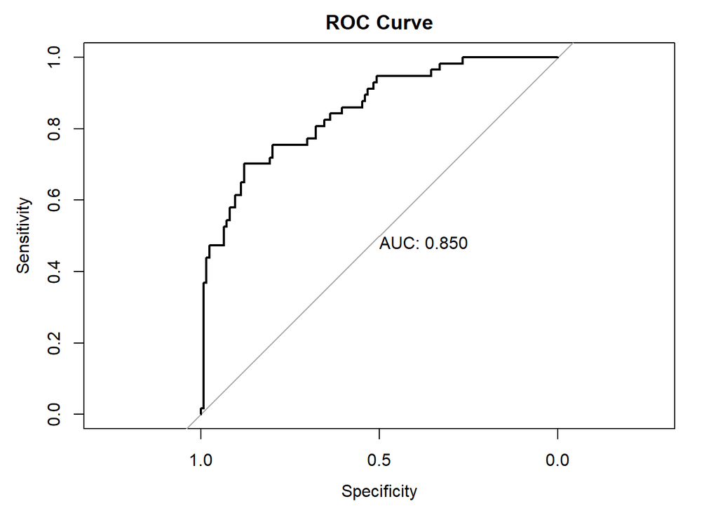

```r
# Create an ROC curve
roc_curve <- roc(response = df$class, predictor = df$scored.probability)
# Plot the ROC curve
plot(roc_curve, print.auc = TRUE, main = "ROC Curve")
```

```r
# Calculate AUC
auc_value <- auc(roc_curve)
cat('AUC (pROC):', auc_value, '\n')
```

```
## AUC (pROC): 0.8503113
```

Comparing the results with our own functions:

The pROC package provides a convenient and widely used method for generating ROC curves and calculating AUC in R.

The custom functions can be useful for specific metrics like precision, error rate, sensitivity, and specificity, which are not directly calculated by the pROC package.

The pROC package offers various customization options for ROC curve plots, including confidence intervals, smoothing, and other visualization features.